# Customer Churn and Revenue Risk

A reproducible, simulated business analytics example

Author

DADM classroom demonstration

Published

November 18, 2026

## Business question and data status

A telecommunications company wants to understand where cancellations and recurring-revenue exposure are concentrated. This teaching data set is **simulated** with a fixed random seed; monthly prices use USD solely as an illustrative unit. It contains no real customer records and must not be cited as industry evidence. The script in `data/generate_simulated_data.R` explains the rules that generated it.

## Import and inspect

`read_csv()` imports the comma-separated file and infers column types. Check the number of rows, names, types, and missing values before interpreting a summary.

```r
library(readr)
library(dplyr)
library(ggplot2)

customers_raw <- read_csv("data/customer_churn_simulated.csv", show_col_types = FALSE)
glimpse(customers_raw)
```

```
Rows: 600
Columns: 7
$ customer_id      <chr> "C0001", "C0002", "C0003", "C0004", "C0005", "C0006",…
$ contract         <chr> "Month-to-month", "Month-to-month", "One year", "Mont…
$ tenure_months    <dbl> 25, 30, 25, 33, 37, 49, 22, 21, 70, 25, 11, 23, 20, 6…
$ support_tickets  <dbl> 1, 3, 3, 1, 0, 0, 5, 2, 2, 4, 3, 0, 1, 1, 2, 0, 1, 2,…
$ internet_service <chr> "No internet", "DSL", "No internet", "No internet", "…
$ monthly_charge   <dbl> 18.00, 57.73, 39.79, 26.69, 44.19, 59.58, 44.99, 81.4…
$ churn            <chr> "Yes", "No", "No", "No", "No", "No", "No", "Yes", "No…
```

```r
summarise(customers_raw,
          customers = n(),
          missing_monthly_charge = sum(is.na(monthly_charge)))
```

```
# A tibble: 1 × 2
  customers missing_monthly_charge
      <int>                  <int>
1       600                     18
```

## Clean and create analysis variables

Missing monthly charges are imputed with the median among customers on the same contract type. This preserves plan-level price differences better than one overall median. We retain and report the number imputed. Tenure is grouped into three readable bands.

```r
missing_charge_n <- sum(is.na(customers_raw$monthly_charge))

contract_medians <- customers_raw |>
  group_by(contract) |>
  summarise(contract_median = median(monthly_charge, na.rm = TRUE), .groups = "drop")

customers <- customers_raw |>
  left_join(contract_medians, by = "contract") |>
  mutate(
    monthly_charge = if_else(is.na(monthly_charge), contract_median, monthly_charge),
    contract = factor(contract, levels = c("Month-to-month", "One year", "Two year")),
    tenure_band = cut(tenure_months, breaks = c(0, 12, 36, Inf),
                      labels = c("0–12 months", "13–36 months", "37+ months")),
    churn_flag = as.integer(churn == "Yes"),
    monthly_revenue = monthly_charge
  ) |>
  select(-contract_median)

missing_charge_n
```

```
[1] 18
```

```r
summary(customers$monthly_charge)
```

```
   Min. 1st Qu.  Median    Mean 3rd Qu.    Max.
  18.00   50.50   64.91   63.25   77.83  110.20
```

Imputation makes the revenue summaries possible but can change group means; it does not restore unknown individual charges.

## Summarize churn by segment

A churn rate is a proportion, so the denominator is all customers in the segment. The table reports sample size alongside rate.

```r
contract_summary <- customers |>
  group_by(contract) |>
  summarise(
    customers = n(),
    churned = sum(churn_flag),
    churn_rate = mean(churn_flag),
    churned_mrr = sum(monthly_revenue[churn_flag == 1]),
    .groups = "drop"
  ) |>
  arrange(desc(churn_rate))

contract_summary
```

```
# A tibble: 3 × 5
  contract       customers churned churn_rate churned_mrr
  <fct>              <int>   <int>      <dbl>       <dbl>
1 Month-to-month       330      72     0.218        4712.
2 Two year              97      10     0.103         587.
3 One year             173      12     0.0694        815.
```

The churned MRR is the sum of monthly charges associated with observed churned accounts. It is not annual loss or a causal estimate.

## Compare tenure and contract patterns

```r
tenure_summary <- customers |>
  group_by(tenure_band) |>
  summarise(customers = n(), churn_rate = mean(churn_flag), .groups = "drop")

segment_summary <- customers |>
  group_by(contract, tenure_band) |>
  summarise(customers = n(), churn_rate = mean(churn_flag),
            active_mrr = sum(monthly_revenue[churn_flag == 0]),
            churned_mrr = sum(monthly_revenue[churn_flag == 1]),
            .groups = "drop")

tenure_summary
```

```
# A tibble: 3 × 3
  tenure_band  customers churn_rate
  <fct>            <int>      <dbl>
1 0–12 months        129     0.217
2 13–36 months       345     0.165
3 37+ months         126     0.0714
```

```r
segment_summary
```

```
# A tibble: 9 × 6
  contract       tenure_band  customers churn_rate active_mrr churned_mrr
  <fct>          <fct>            <int>      <dbl>      <dbl>       <dbl>
1 Month-to-month 0–12 months         76     0.289       3291.      1353.
2 Month-to-month 13–36 months       181     0.232       8619.      2779.
3 Month-to-month 37+ months          73     0.110       4156.       580.
4 One year       0–12 months         38     0.105       2239.       275.
5 One year       13–36 months       101     0.0792      5822.       540.
6 One year       37+ months          34     0           1973.         0
7 Two year       0–12 months         15     0.133        886.       123.
8 Two year       13–36 months        63     0.111       3674.       394.
9 Two year       37+ months          19     0.0526      1174.        70.2
```

## Visualize rate and revenue exposure

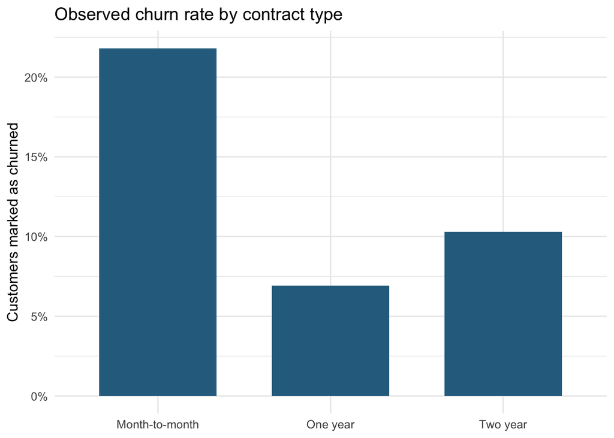

```r
ggplot(contract_summary, aes(x = contract, y = churn_rate)) +
  geom_col(fill = "#2C6E8F", width = .68) +
  scale_y_continuous(labels = scales::label_percent(accuracy = 1),
                     limits = c(0, NA)) +
  labs(title = "Observed churn rate by contract type",
       x = NULL, y = "Customers marked as churned") +
  theme_minimal(base_size = 12)
```

A separate measure makes the financial scale visible. The scenario estimate applies each contract group’s observed rate to its active monthly revenue. It is a rough prioritization device, not a forecast.

```r
revenue_risk <- customers |>
  group_by(contract) |>
  summarise(
    active_customers = sum(churn_flag == 0),
    observed_churn_rate = mean(churn_flag),
    active_mrr = sum(monthly_revenue[churn_flag == 0]),
    observed_churned_mrr = sum(monthly_revenue[churn_flag == 1]),
    illustrative_next_period_exposure = active_mrr * observed_churn_rate,
    .groups = "drop"
  )

revenue_risk
```

```
# A tibble: 3 × 6
  contract  active_customers observed_churn_rate active_mrr observed_churned_mrr
  <fct>                <int>               <dbl>      <dbl>                <dbl>
1 Month-to…              258              0.218      16066.                4712.
2 One year               161              0.0694     10035.                 815.
3 Two year                87              0.103       5734.                 587.
# ℹ 1 more variable: illustrative_next_period_exposure <dbl>
```

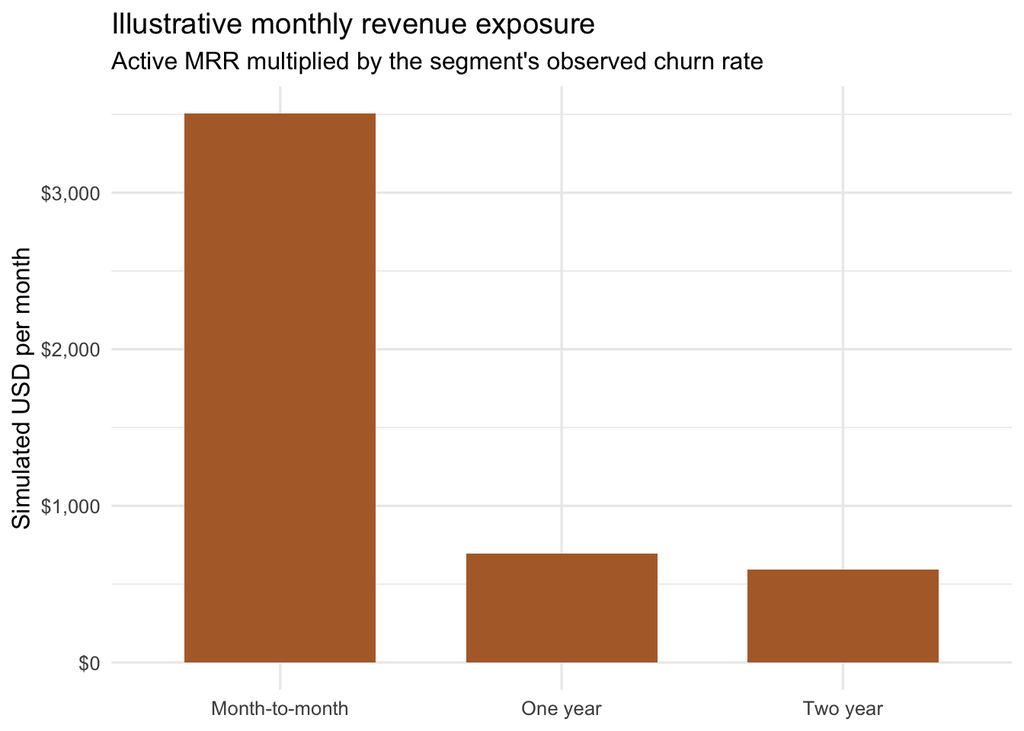

```r
ggplot(revenue_risk, aes(x = contract, y = illustrative_next_period_exposure)) +
  geom_col(fill = "#B36B35", width = .68) +
  scale_y_continuous(labels = scales::label_dollar(prefix = "$", accuracy = 1)) +
  labs(title = "Illustrative monthly revenue exposure",
       subtitle = "Active MRR multiplied by the segment's observed churn rate",
       x = NULL, y = "Simulated USD per month") +
  theme_minimal(base_size = 12)
```

## Interpretation and decision limits

Read the rate, group size, and currency measure together. A high churn rate in a small segment does not automatically imply the largest revenue exposure. The simulated data-generating process intentionally links churn with contract type, tenure, and support contacts, so its patterns cannot establish real-world causes.

Validate measures on a defined period of real, privacy-protected data; check whether billing and churn dates align; and investigate service issues. If the company wants to know whether an offer reduces churn, test it with a credible comparison group. Descriptive differences alone do not identify an intervention effect.